# Population Genetic Analysis using PEGAS

Ian Dworkin

March 21, 2017

You will need to install a new library, PEGAS (Population and Evolutionary Genetic Analysis System). Make sure to allow it to install dependencies as well.

**REMEMBER TO UNCOMMENT THE LINE BELOW**. You only need to install it once!

```r
#install.packages("pegas")
```

Then we need to load this package so R can use it. This should also load in a few additional libraries (like ape)

```r
library(pegas)
```

Let’s load in some data

```r
data(woodmouse)
```

This is a set of 15 sequences of ~ 1KB (so pretty short). They are from the cytochrome b gene of the woodmouse. To see more information type `?woodmouse`

We can take a look at a summary of the data

```r
print(woodmouse)
```

```
## 15 DNA sequences in binary format stored in a matrix.
##
## All sequences of same length: 965
##
## Labels: No305 No304 No306 No0906S No0908S No0909S ...
##
## Base composition:
##     a     c     g     t
## 0.307 0.261 0.126 0.306
```

```r
str(woodmouse)
```

```
##  'DNAbin' raw [1:15, 1:965] n a a a ...
##  - attr(*, "dimnames")=List of 2
##   ..$ : chr [1:15] "No305" "No304" "No306" "No0906S" ...
##   ..$ : NULL
```

Since R does not have a super nice graphical interface for such things, it is sometimes hard to look directly at the sequences. You can get a sense like this (using the alview function). In this case we are looking at the first 50 bp of sequence for the first 5 samples (See how we are indexing it below).

```r
alview(woodmouse[1:5, 1:50])
```

```
##                                                         50
## No305   NTTCGAAAAACACACCCACTACTAAAANTTATCAGTCACTCCTTCATCGA
## No304   A..........................A......AC..............
## No306   A..........................A......A...............
## No0906S A..........................A.C....A...............
## No0908S A..........................A......A...............
```

The first sequence shows the actual DNA sequence for one of the DNA sequences in the sample. Each row represents a different DNA sequence from that sample. The dot “.” represents a short hand to say that the nucleotide is identical (by state) at that site in comparison to the first sequence. If you see a letter it means that that site is polymorphic.

We can make a few simple figures to look at the DNA alignments. These functions work on a special class of object for DNA alignments called `DNAbin`

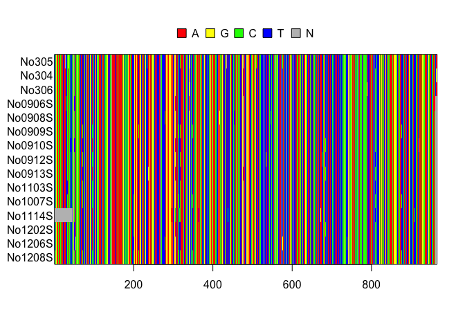

```r
image(woodmouse)
```

While you can spot the polymorphism it is not the clearest picture.

We can also look at specific bases. In this case, let’s look for “n” (where we do not know the base). This gives us a sense of missing data.

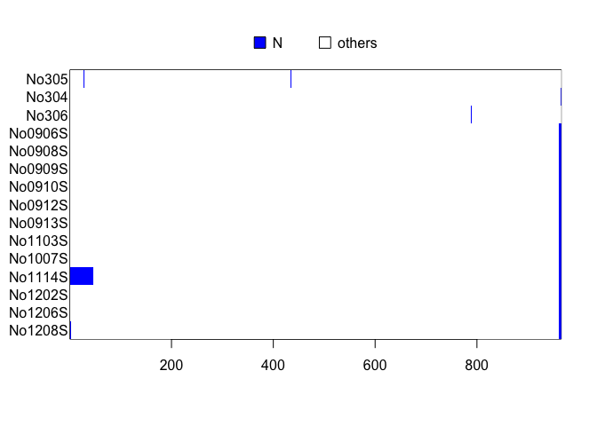

```r
image(woodmouse, "n", "blue")
```

Let’s just look at two sequences over a short stretch of the DNA (100 bp).

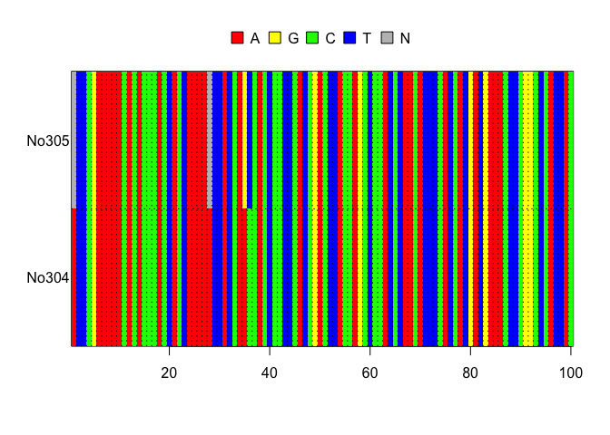

```r
image(woodmouse[1:2, 1:100])
grid(100, 2, col = "black")
```

1. Play around with this to try and locate some of the polymorphic regions in the sequence.

## Site frequency spectrum.

One of the things we want to be able to do is look at the SFS (Site Frequency Spectrum). With an understanding about the expectations of what happens to the SFS under different scenarios involving both natural selection (i.e. positive selection, purifying selection, balancing selection) and demography (population bottlenecks, population expansions, etc) will help you to develop an intuition for what patterns of sequence variation you might see in a sample of DNA sequences. In particular when and how estimators of $\theta = 4N_{e}\mu$ such as number of segregating sites (S), and nucleotide diversity ($\pi$) will provide biased estimates (thus telling you something potentially interesting has happened). This is such a common thing to do, that there is a function in `pegas` to accomplish this (even though it is just some counting).

```r
(sp <- site.spectrum(woodmouse))
```

```
## [1] 33  6  7  4  3  0  1
## attr(,"class")
## [1] "spectrum"
## attr(,"folded")
## [1] TRUE
```

While the SFS is pretty simple in this case, it is still easier to plot it to make sense of it.

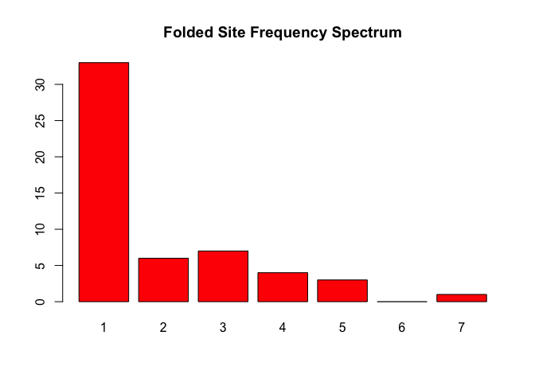

```r
plot(sp)
```

How does this compare to what we would might expect under complete neutrality? Before we can address that (which is best to do using simulations which we will tackle next week I hope) we need to estimate $\theta$ for the sample of DNA sequences.

You will note it says “folded” SFS. This was briefly mentioned in class. It turns out that if we know the ancestral state (i.e. which allele is the “new” derived state, and which is ancestral) we can do a lot more with the SFS. That is called the unfolded SFS. If we are tracking the counts (or frequency) of these, we are able to examine their frequency from 1/n (where n = number of sequences in the sample) to 1.

However, if we don’t know which variant is ancestral and which is derived we can not *polarize* the polymorphism. In such cases we instead ask about the counts of the *minor* allele (the less frequent variant) at each polymorphic site in the DNA sequences that form the sample we are examining. In such a case we can only examine allele frequencies from 1/n to 0.5 (or equivalent if we are just counting.). In this case (since we do not have any information to polarize the sites) we are using the folded SFS.

One thing to note about this SFS is how many sites have *singletons*. i.e. a polymorphic site where only one sequence has the minor allele (i.e. with a frequency of 1/n). While there are important biological explanations for this, please keep in mind that all sequencing technologies produce errors, and most errors will be unique and will thus appear as singletons. So in most analyses investigators attempt to correct for this potential experimental artefact (either with redundant and independent sequencing or by statistically modelling the effect).

2. Examine how the SFS changes as you use subsets of the data (at least 6 sequences please). Also feel free to look at subsets along the length of the sequence. How much does the picture change as you look at subsets of the data?

## Haplotype networks.

We can also examine the relative “genetic distances” among the different sequences by how similar the haplotypes are.

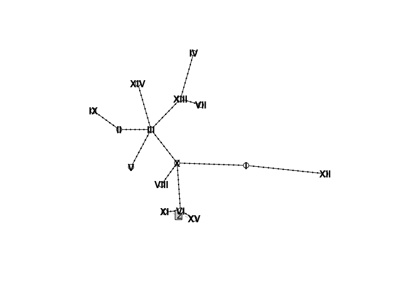

```r
h <- haplotype(woodmouse)
net <- haploNet(h)
plot(net)
```

## Measures of $\theta$

We can now proceed and examine patterns of nucleotide diversity, Segregating sites and how they compare for this set of DNA sequences.

3. Remind yourself about nucleotide diversity ($\pi$), and how it is measured.

We can use the `nuc.div()` function to estimate $\pi$ which is an estimator of $\theta$

```r
nuc.div(woodmouse, pairwise.deletion = TRUE)
```

```
## [1] 0.0132
```

We can go ahead and calculate the number of segregating sites, S as well. The function below shows each site that is segregating.

```r
seg.sites(woodmouse)
```

```
##  [1]  30  33  35  36  42  51  54  60  72  96 106 123 201 213 234 237 279
## [18] 291 297 306 314 316 318 340 342 343 349 365 409 417 438 456 462 477
## [35] 510 514 534 540 546 576 591 672 675 684 697 715 738 810 837 876 909
## [52] 920 957 959 960 963
```

4. How would you show how many segregating sites there are from this?

We can go ahead and get our estimate of theta from the number of segregating sites.

```r
theta.s(woodmouse, variance = TRUE)
```

```
## [1] 17.2 43.1
```

```r
# Or like this...

theta.s(length(seg.sites(woodmouse)),
        n= 15, variance = TRUE)
```

```
## [1] 17.2 43.1
```

## Finally we can examine Tajima’s D.

Let’s remind ourselves of what Tajima’s D is.

What do we expect to see under complete neutrality? (i.e. $\theta = 4N_{e}\mu$ is the only factor influencing diversity in the sample)?

How do we expect our different estimators of theta to change when there is something “more interesting” going on (than just $\theta = 4N_{e}\mu$)?

```r
tajima.test(woodmouse)
```

```
## $D
## [1] -1.37
##
## $Pval.normal
## [1] 0.172
##
## $Pval.beta
## [1] 0.175
```

What does this suggest about the DNA sequences that make up this sample?

5. As we did above, examine subsets of the data. Keep all 15 sequences, but look at subsets along the length of the DNA sequences (i.e. 1:100, 50:150… ). How do the estimates of S, $\pi$ and D change? Why?